# Data Mining Homework1(Building_Permits.csv)

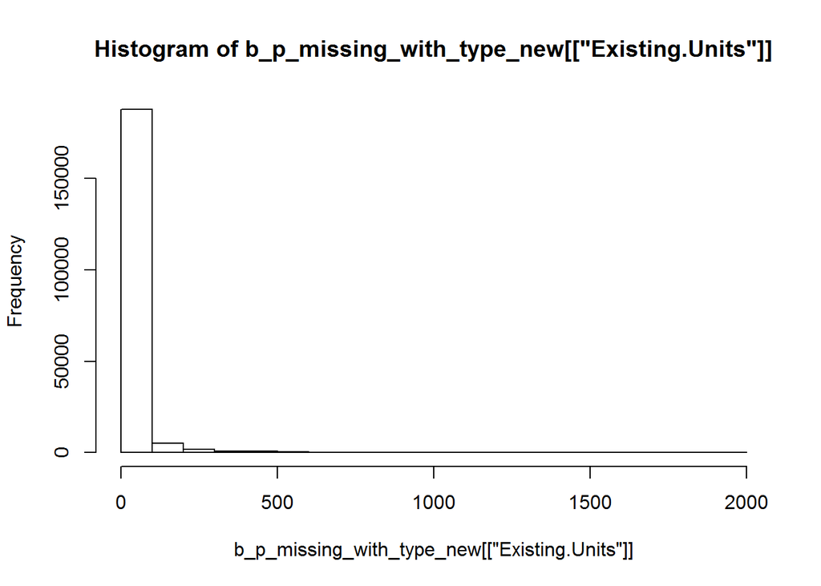

```r
hist(b_p_missing_with_type_new[["Existing.Units"]])
```

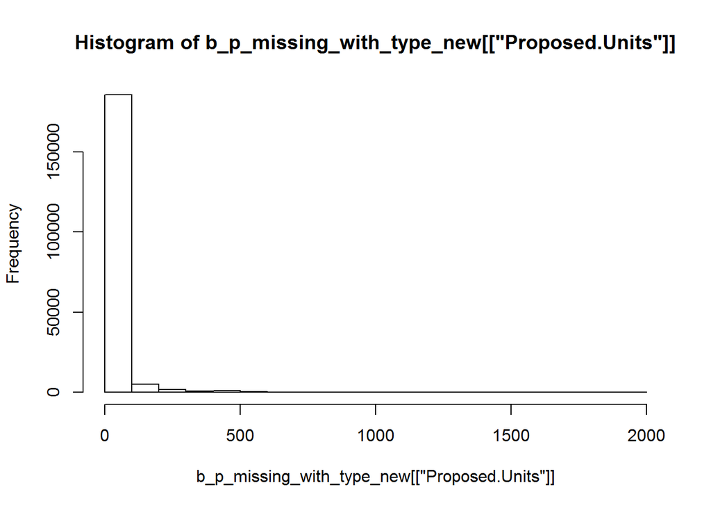

```r
hist(b_p_missing_with_type_new[["Proposed.Units"]])
```

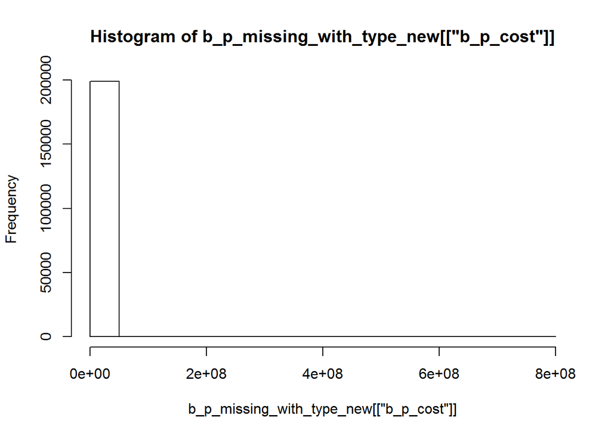

```r
hist(b_p_missing_with_type_new[["b_p_cost"]])
```

Box plot.

```r
boxplot(b_p_missing_with_type_new[["Unit"]])
```

[output not shown]

```r
boxplot(b_p_missing_with_type_new[["Number.of.Existing.Stories"]])
```

[output not shown]

```r
boxplot(b_p_missing_with_type_new[["Number.of.Proposed.Stories"]])
```

[output not shown]

```r
boxplot(b_p_missing_with_type_new[["Existing.Units"]])
```

[output not shown]

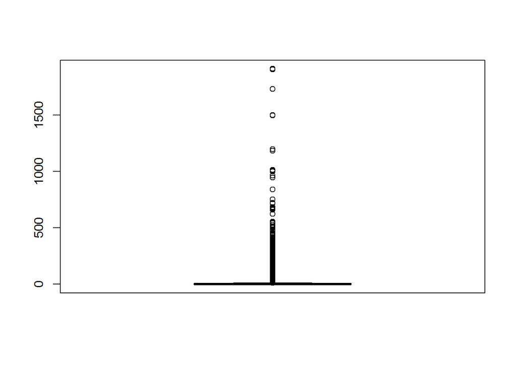

```r
boxplot(b_p_missing_with_type_new[["Proposed.Units"]])
```

```r
boxplot(b_p_missing_with_type_new[["b_p_cost"]])
```

[output not shown]

Deal with missing values by exploring exploring similarities among objects.

This method can be simply described as “The value of a given attribute of objects can be very close to each other if those objects are of the same type”.

The features of each type of permission are described above.

Type1

```r
b_p_numeric_type1_new2<-b_p_numeric_type1
b_p_numeric_type1_new2[which(is.na(b_p_numeric_type1_new[,1])),1]<-round(mean(b_p_numeric_type1[,1],na.rm = TRUE))
b_p_numeric_type1_new2[which(is.na(b_p_numeric_type1_new[,5])),5]<-round(mean(b_p_numeric_type1[,5],na.rm = TRUE))
b_p_numeric_type1_new2[which(is.na(b_p_numeric_type1_new[,7])),7]<-round(mean(b_p_numeric_type1[,7],na.rm = TRUE))
```

Type2

```r
b_p_numeric_type2_new2<-b_p_numeric_type2
b_p_numeric_type2_new2[which(is.na(b_p_numeric_type2_new[,1])),1]<-round(mean(b_p_numeric_type2[,1],na.rm = TRUE))
b_p_numeric_type2_new2[which(is.na(b_p_numeric_type2_new[,5])),5]<-round(mean(b_p_numeric_type2[,5],na.rm = TRUE))
b_p_numeric_type2_new2[which(is.na(b_p_numeric_type2_new[,7])),7]<-round(mean(b_p_numeric_type2[,7],na.rm = TRUE))
```

Type3

```r
b_p_numeric_type3_new2<-b_p_numeric_type3
b_p_numeric_type3_new2[which(is.na(b_p_numeric_type3_new[,1])),1]<-round(mean(b_p_numeric_type3[,1],na.rm = TRUE))
b_p_numeric_type3_new2[which(is.na(b_p_numeric_type3_new[,3])),3]<-round(mean(b_p_numeric_type3[,3],na.rm = TRUE))
b_p_numeric_type3_new2[which(is.na(b_p_numeric_type3_new[,4])),4]<-round(mean(b_p_numeric_type3[,4],na.rm = TRUE))
b_p_numeric_type3_new2[which(is.na(b_p_numeric_type3_new[,5])),5]<-round(mean(b_p_numeric_type3[,5],na.rm = TRUE))
b_p_numeric_type3_new2[which(is.na(b_p_numeric_type3_new[,6])),6]<-round(mean(b_p_numeric_type3[,6],na.rm = TRUE))
b_p_numeric_type3_new2[which(is.na(b_p_numeric_type3_new[,7])),7]<-round(mean(b_p_numeric_type3[,7],na.rm = TRUE))
```

Type4

```r
b_p_numeric_type4_new2<-b_p_numeric_type4
b_p_numeric_type4_new2[which(is.na(b_p_numeric_type4_new[,1])),1]<-round(mean(b_p_numeric_type4[,1],na.rm = TRUE))
b_p_numeric_type4_new2[which(is.na(b_p_numeric_type4_new[,3])),3]<-round(mean(b_p_numeric_type4[,3],na.rm = TRUE))
b_p_numeric_type4_new2[which(is.na(b_p_numeric_type4_new[,4])),4]<-round(mean(b_p_numeric_type4[,4],na.rm = TRUE))
b_p_numeric_type4_new2[which(is.na(b_p_numeric_type4_new[,6])),6]<-round(mean(b_p_numeric_type4[,6],na.rm = TRUE))
```

Type5

```r
b_p_numeric_type5_new2<-b_p_numeric_type5
```

Type6

```r
b_p_numeric_type6_new2<-b_p_numeric_type6
b_p_numeric_type6_new2[which(is.na(b_p_numeric_type6_new[,1])),1]<-round(mean(b_p_numeric_type6[,1],na.rm = TRUE))
b_p_numeric_type6_new2[which(is.na(b_p_numeric_type6_new[,3])),3]<-round(mean(b_p_numeric_type6[,3],na.rm = TRUE))
b_p_numeric_type6_new2[which(is.na(b_p_numeric_type6_new[,4])),4]<-round(mean(b_p_numeric_type6[,4],na.rm = TRUE))
b_p_numeric_type6_new2[which(is.na(b_p_numeric_type6_new[,6])),6]<-round(mean(b_p_numeric_type6[,6],na.rm = TRUE))
```

Type7

```r
b_p_numeric_type7_new2<-b_p_numeric_type7
b_p_numeric_type7_new2[which(is.na(b_p_numeric_type7_new[,1])),1]<-round(mean(b_p_numeric_type7[,1],na.rm = TRUE))
b_p_numeric_type7_new2[which(is.na(b_p_numeric_type7_new[,3])),3]<-round(mean(b_p_numeric_type7[,3],na.rm = TRUE))
```

Type8

```r
b_p_numeric_type8_new2<-b_p_numeric_type8
b_p_numeric_type8_new2[which(is.na(b_p_numeric_type8_new[,1])),1]<-round(mean(b_p_numeric_type8[,1],na.rm = TRUE))
b_p_numeric_type8_new2[which(is.na(b_p_numeric_type8_new[,3])),3]<-round(mean(b_p_numeric_type8[,3],na.rm = TRUE))
b_p_numeric_type8_new2[which(is.na(b_p_numeric_type8_new[,4])),4]<-round(mean(b_p_numeric_type8[,4],na.rm = TRUE))
b_p_numeric_type8_new2[which(is.na(b_p_numeric_type8_new[,5])),5]<-round(mean(b_p_numeric_type8[,5],na.rm = TRUE))
b_p_numeric_type8_new2[which(is.na(b_p_numeric_type8_new[,6])),6]<-round(mean(b_p_numeric_type8[,6],na.rm = TRUE))
b_p_numeric_type8_new2[which(is.na(b_p_numeric_type8_new[,7])),7]<-round(mean(b_p_numeric_type8[,7],na.rm = TRUE))
```

Combine those data and visualize it. Hist plot.

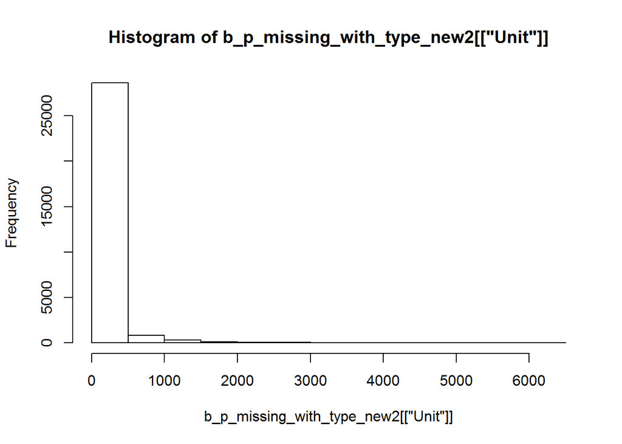

```r
b_p_missing_with_type_new2<-rbind(b_p_numeric_type1_new2[,1:7],b_p_numeric_type2_new2,b_p_numeric_type3_new2,b_p_numeric_type4_new2,b_p_numeric_type5,b_p_numeric_type6_new2,b_p_numeric_type7_new2,b_p_numeric_type8_new2)

hist(b_p_missing_with_type_new2[["Unit"]])
```

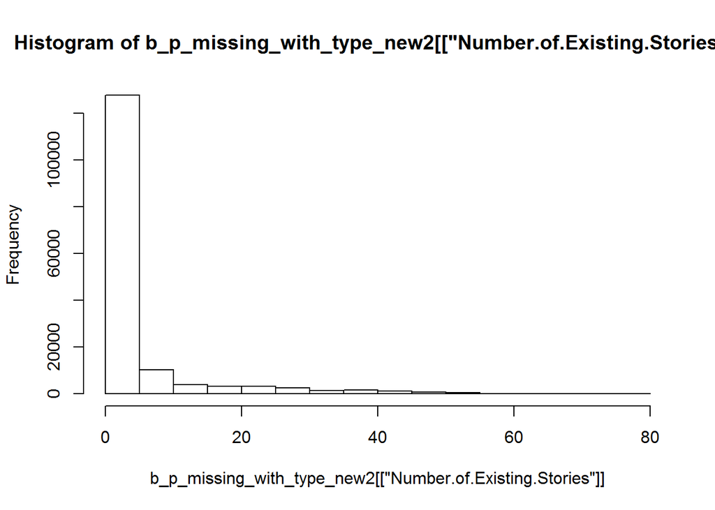

```r
hist(b_p_missing_with_type_new2[["Number.of.Existing.Stories"]])
```

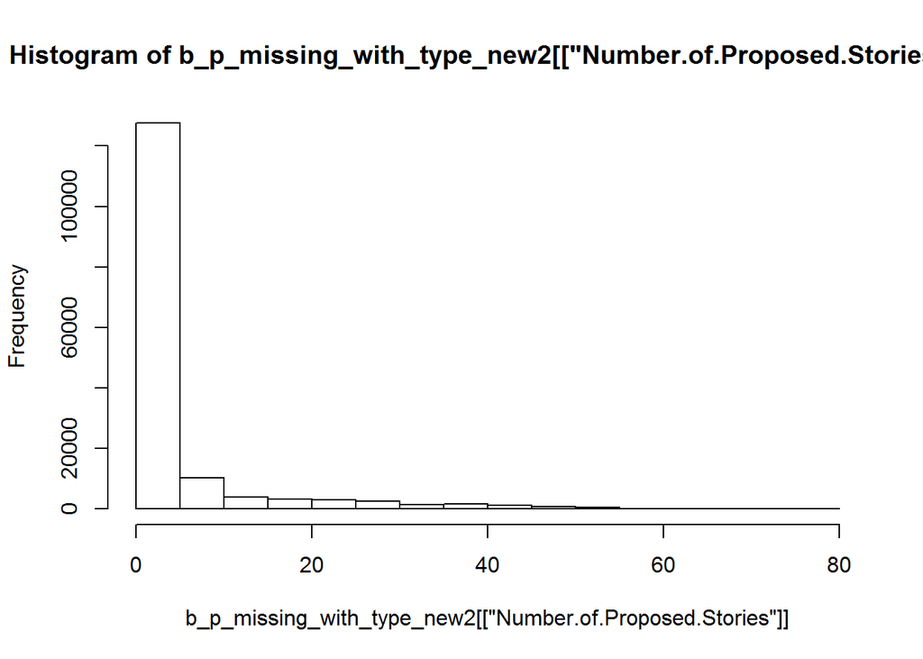

```r
hist(b_p_missing_with_type_new2[["Number.of.Proposed.Stories"]])
```

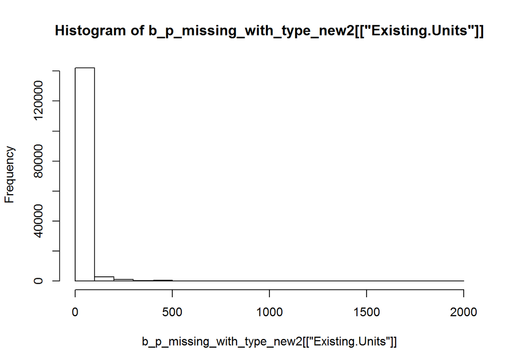

```r
hist(b_p_missing_with_type_new2[["Existing.Units"]])
```

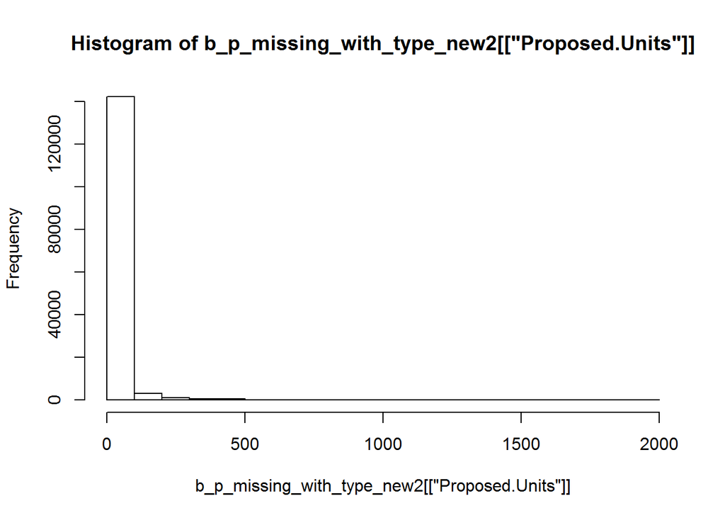

```r
hist(b_p_missing_with_type_new2[["Proposed.Units"]])
```

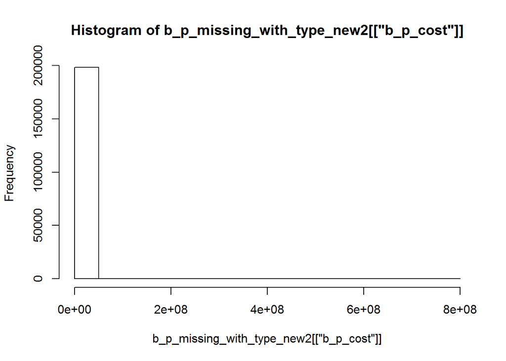

```r
hist(b_p_missing_with_type_new2[["b_p_cost"]])
```

Box plot.

```r
boxplot(b_p_missing_with_type_new2[["Unit"]])
```

[output not shown]

```r
boxplot(b_p_missing_with_type_new2[["Number.of.Existing.Stories"]])
```

[output not shown]

```r
boxplot(b_p_missing_with_type_new2[["Number.of.Proposed.Stories"]])
```

[output not shown]

```r
boxplot(b_p_missing_with_type_new2[["Existing.Units"]])
```

[output not shown]

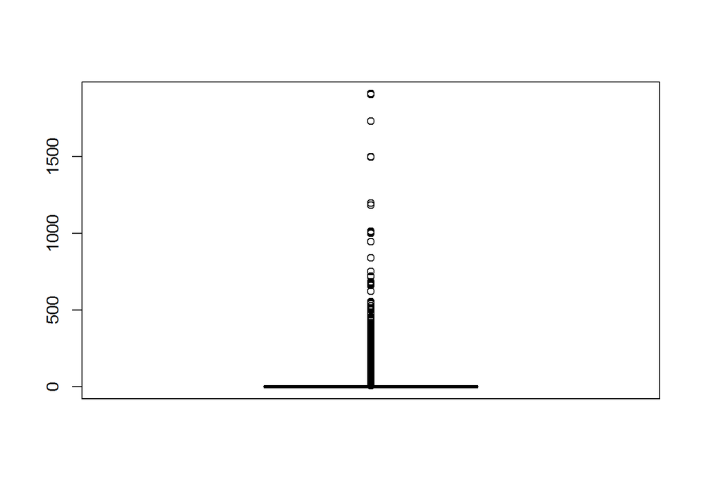

```r
boxplot(b_p_missing_with_type_new2[["Proposed.Units"]])
```

```r
boxplot(b_p_missing_with_type_new2[["b_p_cost"]])
```

[output not shown]